# Title

## Methods

To meet the assumptions of a linear model, specifically, homoscedasticity and normally distributed residuals, we applied a logit transformation to the outcome variables. This helped to stabilize variance and improve the linear relationship between the predictors and the outcomes. We used many predictors while filtering for multicollinearity in order to capture the most possible relationships while giving each variable a fair shot at capturing true relationships.

#### **Linear Regression:**

We began with a multiple linear regression to examine associations between overdose deaths and a range of demographic and social predictors. We chose multiple linear regression first because of simplicity, interpretability, and ability to quantify relationships.

#### **Huber Regression:**

The initial results of the linear regression revealed the presence of outliers and influential data points. In order to account for the outliers, we switched to using a more robust huber linear model which reduces the influence of extreme values while preserving efficiency. We used Cook’s distance to ensure the outliers were not unjustly biasing the model. This approach allowed us to maintain model interpretability and mitigate the effects of counties with unusually high or low rates due to unmeasured local factors.

#### **Random Forest:**

To look further into the data, we used a random forest model to capture nonlinear relationships and variable importance. This provided a flexible non-parametric alternative and confirmed the key predictors identified in the robust linear model.

#### **Data Cleaning:**

To capture a relationship with the real data, we considered using random forests or state means to impute missing values into data. After deliberation, we decided to remove missing values from the response variables to ensure we capture real relationships rather than heuristically correct information. Next, we removed predictors with more than 10% missingness and imputed with both the state means and random forests. Using RMSE we decided that because the results were similar in both while modeling, we would use state means following the ideology of Occams Razor.

## Results

We present the results of the Huber robust linear models and random forest models for each other with the following outcomes: drug overdose deaths, alcohol-impaired driving deaths, and excessive drinking. While rurality itself was not a strong predictor of substance-related harms, several structural factors commonly found in rural and underserved areas were consistently associated with worse outcomes. Below we highlight the five most influential predictors for each outcome based on t-value outcome and significance.

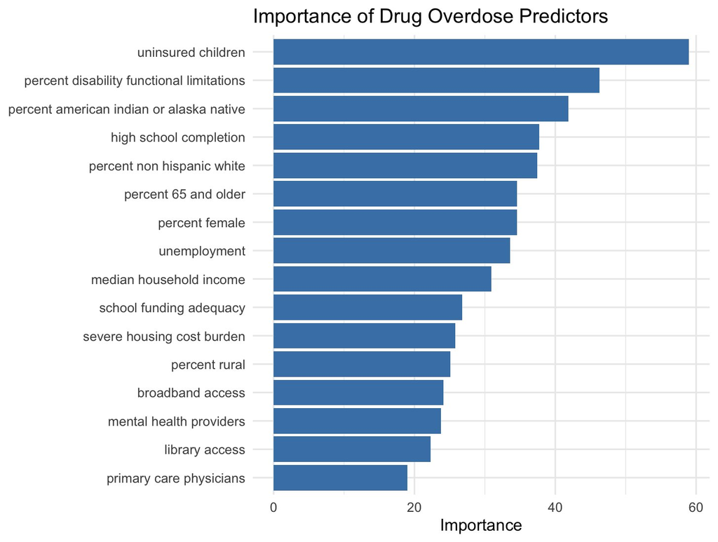

Random Forest Predictor Importance

#### **Drug Overdose Deaths:**

Counties with higher percentages of people living with disabilities had significantly higher drug overdose death rates. Similarly, places with more women and more mental health providers also saw elevated overdose levels. Counties with more American Indian or Alaska Native (AI/AN) residents had slightly higher rates. Interestingly, counties with greater access to mental health providers also had higher overdose rates. This may reflect a pattern where providers are more concentrated in wealthier areas with more resources to report and respond to overdoses, rather than indicating that providers themselves are a risk factor. Conversely, counties with higher rates of uninsured children reported fewer overdose deaths, which could be explained by the fact that overdose tends to affect adults more than children.

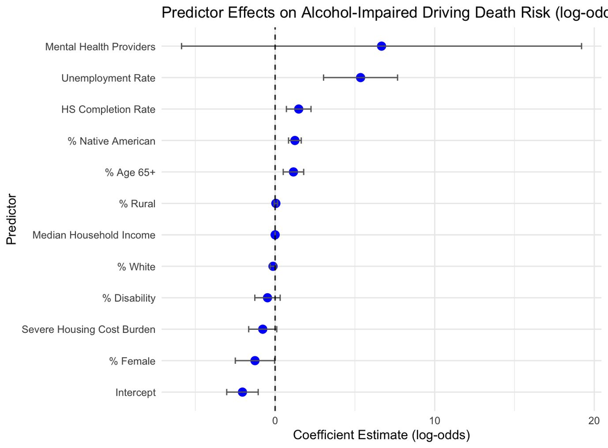

Huber Model Coefficients(Logit)

#### **Alcohol-Impaired Driving Deaths:**

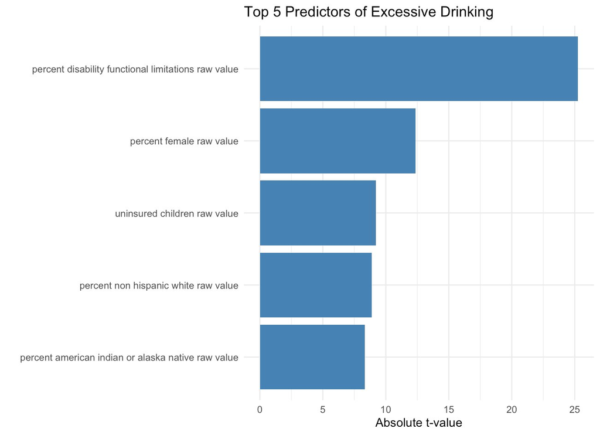

#### **Excessive Drinking:**

Excessive drinking was most common in counties with higher percentages of AI/AN residents and more uninsured children. In contrast, counties with more people who have disabilities or a higher proportion of women tended to have lower excessive drinking rates. The relationship between mental health provider availability and drinking was weaker in this model, but provider presence still offers important context that areas with more providers may be better equipped to recognize and document problematic drinking behaviors, leading to higher reported rates.

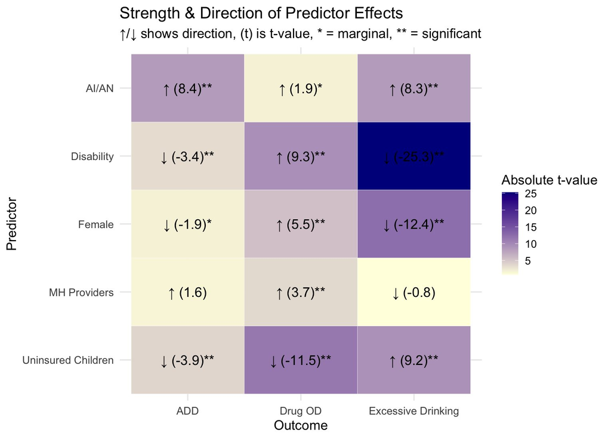

Coefficient Heat Map

## Recommendations

#### **Rurality & Mental Health Providers in Substance Abuse:**

Lastly, we recommend expanding access to care in rural areas. Our data indicates that a lack of insurance—particularly among children is a strong predictor of excessive drinking, suggesting that limited access to care contributes to substance-related harms. Excessive drinking was especially prevalent in counties with higher percentages of American Indian/Alaska Native (AI/AN) residents and more uninsured children, highlighting the role of structural inequities. In contrast, counties with more people with disabilities or a higher proportion of women showed lower rates of excessive drinking.

## Limitations

This analysis has a few limitations that should be considered while interpreting the results.

First, **missing data** on race, ethnicity, and the response variables can bias results and diminish disparities among specific demographics such as American Indians and Alaska Native populations. Additionally, some substance abuse measurements require self-reporting which often leads to underreporting due to recall bias and stigmas leading to possibly underestimating total harm.

Next, data quality and **coverage in rural areas** are concerning. The response variables drug overdose deaths was missing many values within the center of the United States often in rural, unaccounted for areas. These places lack healthcare access because of missing infrastructure which can limit analysis accuracy. Because of this, communities high at risk may be overlooked.

Lastly, the **analysis is only observational** which means we can only make inferences based on cold data. This misses the mechanisms behind predictor and outcome variables leading to correlation based claims over causal relationships. Many of the predictor variables are also interrelated meaning it’s extremely hard to isolate individual effects of predictors on the outcomes.

Altogether, these limitations show the need for cautious interpretations of the data and the need for further causal-based research.

## References

American Addiction Centers. (2025, March 31). *Addiction statistics & demographics*. American Addiction Centers. Retrieved from https://americanaddictioncenters.org/rehab-guide/addiction-statistics-demographics. Accessed July 23, 2025.

Centers for Disease Control and Prevention. (2024, January 23). *Overdose prevention strategies*. U.S. Department of Health & Human Services. Retrieved from https://www.cdc.gov/overdose-prevention/prevention/index.html. Accessed July 23, 2025.

Hoffman, K. L., Milazzo, F., Williams, N. T., Samples, H., Olfson, M., Diaz, I., … Rudolph, K. E. (2024). Independent and joint contributions of physical disability and chronic pain to incident opioid use disorder and opioid overdose among Medicaid patients. Psychological Medicine, 54(7), 1419–1430. doi:10.1017/S003329172300332X.

Jones AA, Segel JE, Skogseth EM, Apsley HB, Santos-Lozada AR. Drug overdose deaths among women 1999-2021 in the United States: Differences by race, ethnicity, and age. Womens Health (Lond). 2024 Jan-Dec;20:17455057241307088. doi: 10.1177/17455057241307088. PMID: 39686730; PMCID: PMC11650567.